M2.883 · Aprendizaje por refuerzo

2023-1 · Máster universitario en Ciencia de datos (*Data science*)

Estudios de Informática, Multimedia y Telecomunicación

# PEC2: Deep Reinforcement Learning

JUAN LARA CHUPS

En esta práctica se implementarán - modelos de DRL en dos entornos diferentes, con el objetivo de analizar distintas formas de aprendizaje de un agente y estudiar su rendimiento. El agente será entrenado con los métodos:

1. DQN
2. Noisy DQN
3. Double DQN

**Importante: La entrega debe hacerse en formato notebook y en formato html donde se vea el código y los resultados y comentarios de cada ejercicio. Para exportar el notebook a html puede hacerse desde el menú File → Download as → HTML.**

## 0. Contexto

El aprendizaje por refuerzo es un campo de la inteligencia artificial que busca desarrollar sistemas capaces de aprender y tomar decisiones autónomas a través de la interacción con su entorno. A lo largo de los años, este enfoque ha demostrado su capacidad para abordar una amplia gama de aplicaciones, desde juegos de mesa hasta robótica y gestión de recursos. Sin embargo, una de las cuestiones más desafiantes en el aprendizaje por refuerzo es la creación de entornos de simulación adecuados que reflejen fielmente el contexto de la aplicación deseada.

En este contexto, esta PEC tiene como objetivo desarrollar un nuevo entorno de simulación que permita la investigación y experimentación con diferentes agentes. Este entorno estará diseñado específicamente para abordar un problema ficticio de conducción autónoma, en el que un coche debe aprender a regular su propia velocidad. Para ello, se utilizará el entorno adaptado a las especificaciones de Gymnasium (https://gymnasium.farama.org/index.html), que permite la creación de entornos de simulación personalizados para el aprendizaje por refuerzo.

### 1. Creación de un entorno en Gym (3 ptos)

En este ejercicio diseñaremos un entorno sencillo siguiendo el esquema de los entornos de `Gymnasium`, y trataremos de resolverlo.

Los entornos de `Gymnasium` suelen tener la siguiente estructura:

```
class FooEnv(gym.Env):
  metadata = {'render.modes': ['human']}

  def __init__(self):
    ...
  def step(self, action):
    ...
    return new_state, reward, terminated, truncated, info

  def reset(self):
    ...
    return observation, info

  def render(self, mode='human', close=False):
    ...
```

El primer paso será instalar las librerías necesarias para abordar la PEC:

```python
!pip install gymnasium==0.28.1
!pip install torch
!pip install matplotlib
!pip install numpy
!pip install tensorboard
!pip install tdqm
!pip install tabulate
```

y las importamos:

```python
import numpy as np
import gymnasium as gym
import random
import matplotlib.pyplot as plt
from gymnasium.spaces import Discrete
from collections import namedtuple, deque
from copy import deepcopy
import math
import time
import torch
import torch.nn.functional as F
from tabulate import tabulate

print("La versión de Gym utilizada en esta PEC es la 0.28.1, compruébalo a continuación")
print("Gym Version:", gym.__version__)  # 0.28.1
print("Torch Version:", torch.__version__)  # 1.13.1
mean_reward_dqn = 0
mean_reward_noisy =0
mean_reward_double =0
episodes_train_dqn = 0
episodes_train_noisy  =0
episodes_train_double =0
```

```
La versión de Gym utilizada en esta PEC es la 0.28.1, compruébalo a continuación
Gym Version: 0.28.1
Torch Version: 2.1.1
```

*¡Enhorabuena!* Tesla ha decidido contrataros para desarrollar un sistema de conducción autónoma para sus vehículos. Para ello, os piden que diseñéis un entorno de simulación que permita entrenar un agente capaz de regular la velocidad de un coche en caso de acercarnos demasiado al vehículo que nos precede. El entorno debe cumplir las siguientes especificaciones:

- El entorno debe llamarse `SpeedRegulationEnv`
- El entorno debe heredar de la clase `gym.Env`
- La velocidad del agente puede oscilar entre los 1 y los 160 Km/h
- La velocidad inicial del agente será de 100 +-20 Km/h
- El regulador de velocidad del coche puede acelerar, mantener la velocidad o frenar en una escala de 2 Km/h por segundo. El agente puede realizar la tarea de:
- -2 km/h
- -1 km/h
- +0 km/h
- +1 km/h
- +2 km/h
- La recompensa será de +1 si la distancia del coche de delante se mantien entre 100 y 170 metros y de -1 fuera de estos márgenes
- La distancia será cómo máximo de 1000 metros en todo el juego o de 0 metros. Si se superan estos límites (tanto por arriba como por abajo) se recibe una penalización de -500 puntos y termina el episodio.
- El entorno tendrá una dureción máxima de 350 segundos
- El vehículo no debe aumentar la velocidad en más de 120 km/h, en ese caso, recibe una recompensa de -1 punto independientemente de la distancia
- El sistema se activa cuando circulamos a 70 metros de un coche objetivo. Es decir, al iniciar el entorno, la distancia con el coche objetivo es de 70 metros.
- El vehiculo situado delante podrá, como máximo, tener o la misma o hasta -+ 5 km/h que nuestro vehículo al inicio y nunca mayor de 120 km/h. En caso de ser mayor de 120 o menor de 80 se cogeran el mínimo o el máximo citado.  
  Ejemplo: Agente -> 80 Coche objetivo= 80 - 5 el coche objetivo empieza a 80
- El vehiculo situado delante podrá, con respecto a la velocidad inicial en la que se active el agente, aumentar o disminuir la velocidad en 1 con un máximo de 120 y un mínimo de 80 .
- El juego termina cuando el tiempo se agota (se cumplen los 350 segundos)
- Se considera que un agente ha superado el entorno cuando obtiene una puntuación mayor o igual a 260 puntos.

[figure not shown]

**Ejercicio (2,5 ptos):** Define el entorno `SpeedRegulationEnv` siguiendo las indicaciones aportadas anteriormente.

EL primer paso es implementar una función llamada **calcular_distancia** que calculará la distancia entre dos vehículos que se están moviendo a diferentes velocidades.

La función toma tres argumentos:

- speed1_kmph: La velocidad del primer vehículo en kilómetros por hora (km/h).
- speed2_kmph: La velocidad del segundo vehículo en kilómetros por hora (km/h).
- time_seconds (opcional): El tiempo en segundos durante el cual se desea calcular la distancia entre los dos vehículos. Por defecto, se asume un segundo si no se proporciona ningún valor.

La función realizará los siguientes pasos:

1. Convertirá las velocidades de ambos vehículos de kilómetros por hora (km/h) a kilómetros por segundo (km/s).
2. Calculará la distancia recorrida por el primer vehículo en metros durante el tiempo especificado.
3. Calculará la distancia recorrida por el segundo vehículo en metros durante el mismo tiempo especificado.
4. Finalmente, calculará la distancia entre los dos vehículos restando la distancia recorrida por el primer vehículo de la distancia recorrida por el segundo vehículo.

La función devolverá la distancia resultante en metros entre los dos vehículos.

Escribe el código para la función calcular_distancia siguiendo las instrucciones proporcionadas en el enunciado. Luego, prueba la función con diferentes valores de velocidad y tiempo para asegurarte de que funcione correctamente.

A continuación, se muestra la firma de la función:

```python
def calcular_distancia(speed1_kmph, speed2_kmph, time_seconds=1):
    # Convertir la velocidad a kilómetros por segundo (1 hora = 3600 segundos)
    speed1_kmps = speed1_kmph / 3600
    speed2_kmps = speed2_kmph / 3600

    # Calcular la distancia en metros
    dist_m1 = speed1_kmps * time_seconds * 1000
    dist_m2 = speed2_kmps * time_seconds * 1000

    # Calcular la distancia entre los vehículos
    dist_vech = dist_m1 - dist_m2


    return dist_vech
```

Prueba la función y obten la siguiente tabla

[output not shown]

```python
print(calcular_distancia(36, 24 ,15))
print(calcular_distancia(36, 24 ,120))
print(round(calcular_distancia(52, 18 ,1),2))
print(calcular_distancia(40, 40 ,15))
```

```
50.0
400.0
9.44
0.0
```

**Ejercicio :** Diseña el entorno `SpeedRegulationEnv` con las características indicadas. Importante: Modifica todas las variables inicializadas a None

Por si es de ayuda, te dejo la siguiente tabla:

| Velocidad del coche | Distancia al coche objetivo | Recompensa |
| --- | --- | --- |
| Menor que 0 o mayor que 160 Km/h | Cualquier valor | -500 |
| Velocidad entre 1 y 120 Km/h | Entre 100 y 170 metros | +1 |
| Cualquier valor | Distancia menor que 0 o mayor que 1000 metros | -500 |
| Resto | Resto | -1 |

```python
class SpeedRegulationEnv(gym.Env):
    def __init__(self):
        '''
        Argumentos:
            - espacio de acciones
            - espacio de observaciones (se recomienda usar la función Box)
            - estado inicial
            - duración episodio
        '''
        ###TODO: inicializar variables###
        self.action_space = gym.spaces.Discrete(5) #acciones posibles
        self.min_vel_car_agent = 1  #velocidad mínima del agente.
        self.max_vel_car_agent =  160 #velocidad máxima del agente.
        self.min_vel_car_objective = 80  #velocidad mínima del coche objetivo
        self.max_vel_car_objective  =  120 #velocidad máxima del coche objetivo
        self.min_distance = 0 # distancia mínima del juego
        self.max_distance =  1000  #distáncia máxima del juego
        self.observation_space  = gym.spaces.Box(low=np.array([self.min_vel_car_agent, self.min_distance]),
                                                 high=np.array([self.max_vel_car_agent,self.max_distance]),
                                                 dtype=int)
        self.speed_car = np.random.randint(80, 120) #velocidad inicial al inicio del juego.
        self.speed_car_objective = np.clip(self.speed_car + np.random.uniform(-5, 6), self.min_vel_car_objective, self.max_vel_car_objective) #velocidad coche delante al inicio
        self.distance_initial = 70 #distancia entre los vehiculos al inicio del juego
        self.execution_time = 350  #tiempo ejecución  máxima del agente
        self.execution = 0
        self.distance = self.distance_initial # creamos la variable instancia distance
        self.state = [self.speed_car ,self.distance]

        ####



    def step(self, action):
        '''
        Argumentos:
            - velocidad según acción tomada
            - disminución tiempo de juego
        '''

        ###TODO: nueva velocidad y reducción del tiempo de juego###
        action = action - 2


        #almacenamos la acción
        self.speed_car += action
        #aplicamos la reducción del segundo.
        self.execution += 1

        # Aplicamos la corrección del coche de delante.
        self.speed_car_objective += np.random.choice([-1, 1])
        #revisamos que este dentro del rango permitido.
        self.speed_car_objective = np.clip(self.speed_car_objective, 80, 120)

        #cálculo de la distancia.
        self.distance = self.distance - round(calcular_distancia(self.speed_car, self.speed_car_objective, 1))

        ###TODO: Cálculo de las recompensas###
        truncated = False
        terminated = False

        #comprovación de que el coche, aplicada la acción, tiene una velocidad entre el rango permitido.
        if self.speed_car  < 1  or  self.speed_car  > 160:
            reward = -500
            truncated = True

        #comprovación de que el coche, aplicada la acción, tiene la distancia objetivo
        if not truncated and  100 <= self.distance <= 170  and 1 <= self.speed_car <= 120:
            reward = +1
        else:
            #comprovación de que el coche está en el rango acordado.
            if self.distance > 1000  or self.distance <= 0:
                reward = -500
                truncated = True
            else:
                reward = -1

        ###TODO: Comprobar si el tiempo del agente se ha agotado###
        if self.execution == 350:
          terminated = True

        ###

        self.state = [self.speed_car, self.distance]
        # info en blanco
        info = {}

        # Return información del paso.
        return self.state , reward, terminated, truncated, info


    def reset(self):
        '''
        Argumentos:
            - resetear temperatura inicial
            - resetear tiempo de baño
        '''
        ###TODO: resetear variables
        self.speed_car = np.random.randint(80, 120)
        self.speed_car_objective = np.clip(self.speed_car + np.random.choice([-5, 0, 5]), self.min_vel_car_objective, self.max_vel_car_objective)
        self.distance_initial = 70
        self.distance = self.distance_initial
        self.state = [self.speed_car ,self.distance]
        self.execution = 0
        return self.state,{}
        ###

    def render(self, mode='human', close=False):
            print("\r"+ "|" + "-"  +  "1" + "-" * int(self.distance /10) + "2" + "-" + "|  ******  "
                  +"Distancia entre coches: {:.2f} Velocidad coche objetivo: {:.2f} Velocidad agente: "
                   "{}\t\t".format(self.distance, self.speed_car_objective, self.speed_car), end="")
```

**Ejercicio (0.5 pto):** Cargar el entorno `SpeedRegulationEnv` y realizar las siguientes tareas:

- Mostrar el espacio de acciones y el espacio de observaciones.
- Ejecutar 10 episodios con acciones aleatorias, mostrando el episodio y la recompensa obtenida.
- Ejecutar 1 episodio con acciones aleatorias, mostrando cada step con la función render() y la recompensa obtenida.

```python
env = SpeedRegulationEnv()
```

```python
# Espacio de acciones
print("Espacio de acciones es {} ".format(env.action_space))

# Espacio de observacions
print("Espacio de estados es {} ".format(env.observation_space))
```

```
Espacio de acciones es Discrete(5)
Espacio de estados es Box([1 0], [ 160 1000], (2,), int64)
```

```python
#todo  Ejecutar 10 episodios con acciones aleatorias, mostrando el episodio y la recompensa obtenida.

for episodio in range(1, 11):
    state = env.reset()
    total_reward = 0  # Reiniciar total_reward para cada episodio

    while True:
        action = env.action_space.sample()
        state, reward, terminated, truncated, info = env.step(action)
        total_reward += reward

        # Verificar si el episodio ha terminado
        if terminated or truncated:
            break


    print(f"Episodio: {episodio}, Recompensa Total: {total_reward}")
```

```
Episodio: 1, Recompensa Total: -564
Episodio: 2, Recompensa Total: -534
Episodio: 3, Recompensa Total: -715
Episodio: 4, Recompensa Total: -574
Episodio: 5, Recompensa Total: -718
Episodio: 6, Recompensa Total: -624
Episodio: 7, Recompensa Total: -555
Episodio: 8, Recompensa Total: -653
Episodio: 9, Recompensa Total: -587
Episodio: 10, Recompensa Total: -539
```

```python
#todo Ejecutar 1 episodio con acciones aleatorias, mostrando cada step con la función render() y la recompensa obtenida.

episodio = 1
state = env.reset()
total_reward = 0  # Reiniciar total_reward para cada episodio

# Mostrar información de la posición inicial y la variable self.execution
print(f"Posición Inicial: {state}")

while True:
    action = env.action_space.sample()
    state, reward, terminated, truncated, info = env.step(action)
    env.render()  # Llamar a render para imprimir el estado actual y la recompensa
    total_reward += reward

    # Mostrar información completa de cada paso y el valor de self.execution
    print(f"Acción: {action}, Recompensa: {reward}, Recompensa Total: {total_reward}")

    # Verificar si el episodio ha terminado
    if terminated or truncated:
        break
```

```
Posición Inicial: ([114, 70], {})
|-1-------2-|  ******  Distancia entre coches: 71.00 Velocidad coche objetivo: 118.00 Velocidad agente: 116		Acción: 4, Recompensa: -1, Recompensa Total: -1
|-1-------2-|  ******  Distancia entre coches: 71.00 Velocidad coche objetivo: 117.00 Velocidad agente: 118		Acción: 4, Recompensa: -1, Recompensa Total: -2
|-1-------2-|  ******  Distancia entre coches: 70.00 Velocidad coche objetivo: 116.00 Velocidad agente: 119		Acción: 3, Recompensa: -1, Recompensa Total: -3
|-1------2-|  ******  Distancia entre coches: 69.00 Velocidad coche objetivo: 115.00 Velocidad agente: 118		Acción: 1, Recompensa: -1, Recompensa Total: -4
|-1------2-|  ******  Distancia entre coches: 68.00 Velocidad coche objetivo: 114.00 Velocidad agente: 119		Acción: 3, Recompensa: -1, Recompensa Total: -5
|-1------2-|  ******  Distancia entre coches: 66.00 Velocidad coche objetivo: 113.00 Velocidad agente: 121		Acción: 4, Recompensa: -1, Recompensa Total: -6
|-1------2-|  ******  Distancia entre coches: 63.00 Velocidad coche objetivo: 112.00 Velocidad agente: 121		Acción: 2, Recompensa: -1, Recompensa Total: -7
|-1------2-|  ******  Distancia entre coches: 60.00 Velocidad coche objetivo: 113.00 Velocidad agente: 123		Acción: 4, Recompensa: -1, Recompensa Total: -8
|-1-----2-|  ******  Distancia entre coches: 58.00 Velocidad coche objetivo: 114.00 Velocidad agente: 121		Acción: 0, Recompensa: -1, Recompensa Total: -9
|-1-----2-|  ******  Distancia entre coches: 56.00 Velocidad coche objetivo: 113.00 Velocidad agente: 120		Acción: 1, Recompensa: -1, Recompensa Total: -10
|-1-----2-|  ******  Distancia entre coches: 54.00 Velocidad coche objetivo: 114.00 Velocidad agente: 120		Acción: 2, Recompensa: -1, Recompensa Total: -11
|-1-----2-|  ******  Distancia entre coches: 53.00 Velocidad coche objetivo: 115.00 Velocidad agente: 119		Acción: 1, Recompensa: -1, Recompensa Total: -12
|-1-----2-|  ******  Distancia entre coches: 52.00 Velocidad coche objetivo: 116.00 Velocidad agente: 120		Acción: 3, Recompensa: -1, Recompensa Total: -13
|-1-----2-|  ******  Distancia entre coches: 51.00 Velocidad coche objetivo: 115.00 Velocidad agente: 118		Acción: 0, Recompensa: -1, Recompensa Total: -14
|-1-----2-|  ******  Distancia entre coches: 50.00 Velocidad coche objetivo: 114.00 Velocidad agente: 118		Acción: 2, Recompensa: -1, Recompensa Total: -15
|-1----2-|  ******  Distancia entre coches: 49.00 Velocidad coche objetivo: 115.00 Velocidad agente: 118		Acción: 2, Recompensa: -1, Recompensa Total: -16
|-1----2-|  ******  Distancia entre coches: 47.00 Velocidad coche objetivo: 114.00 Velocidad agente: 120		Acción: 4, Recompensa: -1, Recompensa Total: -17
|-1----2-|  ******  Distancia entre coches: 46.00 Velocidad coche objetivo: 115.00 Velocidad agente: 120		Acción: 2, Recompensa: -1, Recompensa Total: -18
|-1----2-|  ******  Distancia entre coches: 44.00 Velocidad coche objetivo: 114.00 Velocidad agente: 121		Acción: 3, Recompensa: -1, Recompensa Total: -19
|-1----2-|  ******  Distancia entre coches: 42.00 Velocidad coche objetivo: 115.00 Velocidad agente: 122		Acción: 3, Recompensa: -1, Recompensa Total: -20
|-1----2-|  ******  Distancia entre coches: 40.00 Velocidad coche objetivo: 114.00 Velocidad agente: 123		Acción: 3, Recompensa: -1, Recompensa Total: -21
|-1---2-|  ******  Distancia entre coches: 38.00 Velocidad coche objetivo: 113.00 Velocidad agente: 121		Acción: 0, Recompensa: -1, Recompensa Total: -22
|-1---2-|  ******  Distancia entre coches: 36.00 Velocidad coche objetivo: 114.00 Velocidad agente: 123		Acción: 4, Recompensa: -1, Recompensa Total: -23
|-1---2-|  ******  Distancia entre coches: 33.00 Velocidad coche objetivo: 113.00 Velocidad agente: 124		Acción: 3, Recompensa: -1, Recompensa Total: -24
|-1---2-|  ******  Distancia entre coches: 30.00 Velocidad coche objetivo: 114.00 Velocidad agente: 126		Acción: 4, Recompensa: -1, Recompensa Total: -25
|-1--2-|  ******  Distancia entre coches: 26.00 Velocidad coche objetivo: 113.00 Velocidad agente: 127		Acción: 3, Recompensa: -1, Recompensa Total: -26
|-1--2-|  ******  Distancia entre coches: 22.00 Velocidad coche objetivo: 114.00 Velocidad agente: 128		Acción: 3, Recompensa: -1, Recompensa Total: -27
|-1-2-|  ******  Distancia entre coches: 18.00 Velocidad coche objetivo: 113.00 Velocidad agente: 128		Acción: 2, Recompensa: -1, Recompensa Total: -28
|-1-2-|  ******  Distancia entre coches: 14.00 Velocidad coche objetivo: 114.00 Velocidad agente: 128		Acción: 2, Recompensa: -1, Recompensa Total: -29
|-1-2-|  ******  Distancia entre coches: 10.00 Velocidad coche objetivo: 115.00 Velocidad agente: 130		Acción: 4, Recompensa: -1, Recompensa Total: -30
|-12-|  ******  Distancia entre coches: 6.00 Velocidad coche objetivo: 114.00 Velocidad agente: 130		Acción: 2, Recompensa: -1, Recompensa Total: -31
|-12-|  ******  Distancia entre coches: 1.00 Velocidad coche objetivo: 113.00 Velocidad agente: 131		Acción: 3, Recompensa: -1, Recompensa Total: -32
|-12-|  ******  Distancia entre coches: -5.00 Velocidad coche objetivo: 112.00 Velocidad agente: 132		Acción: 3, Recompensa: -500, Recompensa Total: -532
```

### 2. Agente DQN regulador de la velocidad (2 ptos)

En este apartado implementaremos una DQN teniendo en cuenta la exploración-explotación (epsilon-*greedy*), la red objetivo, y el buffer de repetición de experiencias.

Definiremos el buffer como sigue:

```python
class experienceReplayBuffer:

    def __init__(self, memory_size=50000, burn_in=10000):
        self.memory_size = memory_size
        self.burn_in = burn_in
        self.buffer = namedtuple('Buffer',
            field_names=['state', 'action', 'reward', 'done', 'next_state'])
        self.replay_memory = deque(maxlen=memory_size)

    def sample_batch(self, batch_size=32):
        samples = np.random.choice(len(self.replay_memory), batch_size,
                                   replace=False)
        # Use asterisk operator to unpack deque
        batch = zip(*[self.replay_memory[i] for i in samples])
        return batch

    def append(self, state, action, reward, done, next_state):
        self.replay_memory.append(
            self.buffer(state, action, reward, done, next_state))

    def burn_in_capacity(self):
        return len(self.replay_memory) / self.burn_in
```

Primeramente implementaremos la red neuronal, utilizando un modelo Secuencial con la siguiente configuración:

- Dos capas completamente conectadas (representadas en pytorch por nn.Lineal) con 128 y 64 neuronas cada una, bias=True, y activación ReLU
- Una capa de salida completamente conectada y bias=True

Usaremos el optimizador Adam para entrenar la red.

**Ejercicio (0.5 ptos):** Implementar la clase `NeuralNetControlSpeed()`. Inicializar las variables necesarias y definir el modelo Secuencial de red neuronal indicado. ----------------------------------------------------------------------------------------------------------- **Nota**: se os proporciona el código pre-implementado. La implementación que se pide en el enunciado está indicada en los bloques *TODO* y/o con variables igualadas a *None*.

```python
class NeuralNetControlSpeed(torch.nn.Module):

    ###################################
    ###inicialización y modelo###
    def __init__(self, env, learning_rate=1e-3,device='cpu'):

        """
        Params
        ======
        n_inputs: tamaño del espacio de estados
        n_outputs: tamaño del espacio de acciones
        actions: array de acciones posibles
        """
        ######################################
        ##TODO: Inicializar parámetros
        super(NeuralNetControlSpeed, self).__init__()
        self.n_inputs = env.observation_space.shape[0]
        self.n_outputs = env.action_space.n
        self.actions = np.arange(env.action_space.n)
        self.learning_rate = learning_rate
        self.device = device


        #######################################
        ##Construcción de la red neuronal
        #######################################
        ##Construcción de la red neuronal
        self.model = torch.nn.Sequential(
            torch.nn.Linear(self.n_inputs, 128),
            torch.nn.ReLU(),
            torch.nn.Linear(128, 64),
            torch.nn.ReLU(),
            torch.nn.Linear(64, self.n_outputs, bias=True)
        )

        if self.device == 'cuda':
            self.model.cuda()

        #######################################
        ##Inicializar el optimizador
        self.optimizer = torch.optim.Adam(self.model.parameters(),
                                          lr=self.learning_rate)

    ### Método e-greedy

    def get_action(self, state, epsilon=0.05):
      if np.random.random() < epsilon:
            action = np.random.choice(self.actions)  # acción aleatoria
      else:
            qvals = self.get_qvals(state)  # acción a partir del cálculo del valor de Q para esa acción
            action= torch.max(qvals, dim=-1)[1].item()
      return action


    def get_qvals(self, state):
      if type(state) is tuple:
        state = np.array([np.ravel(s) for s in state])
      else:
        state = [state]
          #state_t = torch.FloatTensor(state)
      state_t = torch.FloatTensor(state).to(device=self.device) # Se agrega la opción de usar cuda
      return self.model(state_t)
```

A continuación implementaremos una clase que defina el comportamiento del agente DQN teniendo en cuenta:

La exploración/explotación (decaimiento de epsilon) La actualización y sincronización de la red principal y la red objetivo (pérdida) Consideraremos que el agente ha aprendido a realizar la tarea (i.e. el "juego" termina) cuando obtiene una media de mínimo 260 puntos durante 100 episodios consecutivos.

**Ejercicio (0.75 ptos):** Implementar los siguientes puntos de la clase `DQNAgent()`:

1. Declarar las variables de la clase
2. Inicializar las variables necesarias
3. Implementar la acción a tomar
4. Actualizar la red principal según la frecuencia establecida en los hiperparámetros
5. Calcular la pérdida (ecuación Bellman, etc)
6. Sincronizar la red objetivo según la frecuencia establecida en los hiperparámetros
7. Calcular la media de recompensas de los últimos 100 episodios
8. Comprobar límite de episodios
9. Actualizar epsilon según: \begin{equation}\textrm{max}(\epsilon · \epsilon_{\textrm{decay}}, 0.01)\end{equation}

Además, durante el proceso se deben almacenar (*):

1. Las recompensas obtenidas en cada paso del entrenamiento
2. Las recompensas medias cada 100 episodios
3. La pérdida durante el entrenamiento
4. La evolución de epsilon a lo largo del entrenamiento
5. Almacena la cantidad de episodios necesarios para llevar acabo el entrenamiento en la variable **episodes_train_dqn**

----------------------------------------------------------------------------------------------------------- **Nota**: se os proporciona el código pre-implementado. La implementación que se pide en el enunciado está indicada en los bloques *TODO* y/o con variables igualadas a *None*, salvo (*) en qué momento almacenar las variables que se indican.

```python
class DQNAgent:
    def __init__(self, env, main_network, buffer, epsilon=0.1, eps_decay=0.99, batch_size=32):

        ######################################
        ##TODO 1: Declarar variables
        self.env = env
        self.main_network = main_network
        self.target_network = deepcopy(self.main_network)
        self.buffer = buffer
        self.epsilon = epsilon
        self.eps_decay = eps_decay
        self.batch_size = batch_size
        self.nblock = 100
        self.initialize()


    def initialize(self):
        self.update_loss = []
        self.training_loss = []
        self.training_rewards = []
        self.mean_training_rewards = []
        self.sync_eps = []
        self.total_reward = 0
        self.step_count = 0
        self.state0 = self.env.reset()[0]
        self.car_game_state = []
        self.epsilon_evolution = []


    ######################################
    #Tomar paso siguiente
    def take_step(self, eps, mode='train'):
        if mode == 'explore':
            action = random.choice(self.main_network.actions)
        else:
            action = self.main_network.get_action(self.state0, epsilon=eps)

        # Contabilizo el número de steps:

        self.step_count += 1

        #TODO: tomar 'step' i obtener nuevo estado y recompensa. Guardar la experiencia en el buffer
        next_state, reward, terminated, truncated, _ = self.env.step(action)

        done = terminated or truncated

        self.total_reward += reward

        self.buffer.append(self.state0, action, reward, done, next_state)

        #TODO: resetear entorno 'if done'
        if done:
            self.state0 = self.env.reset()[0]
        else:
            self.state0 = next_state

        return done


    ## Entrenamiento
    def train(self, gamma=0.99, max_episodes=50000,
              batch_size=32,
              dnn_update_frequency=4,
              dnn_sync_frequency=2000, REWARD_THRESHOLD = 260):

        self.gamma = gamma

        mean_rewards = 0

        # Rellenamos el buffer con N experiencias aleatorias ()
        print("Filling replay buffer...")
        while self.buffer.burn_in_capacity() < 1:
            self.take_step(self.epsilon, mode='explore')

        episode = 0
        training = True
        print("Training...")
        self.episodes_train_dqn = episode

        while training:
            self.state0 = self.env.reset()[0]
            self.total_reward = 0
            gamedone = False
            while gamedone == False:
                # El agente toma una acción
                gamedone = self.take_step(self.epsilon, mode='train')

                #################################################################################
                #####TODO 4:  Actualizar la red principal según la frecuencia establecida #######
                if self.step_count % dnn_update_frequency == 0:
                    self.update()

                ########################################################################################
                ###TODO 6: Sincronizar red principal y red objetivo según la frecuencia establecida#####
                if self.step_count % dnn_sync_frequency == 0:
                    self.target_network.load_state_dict(self.main_network.state_dict(), strict=False)


                if gamedone:
                    episode += 1
                    self.episodes_train_dqn = episode

                    self.training_loss.append(np.mean(self.update_loss))
                    self.epsilon_evolution.append(self.epsilon)

                    self.update_loss = []

                    #######################################################################################
                    ###TODO 7: calcular la media de recompensa de los últimos X episodios, y almacenar#####
                    self.training_rewards.append(self.total_reward)
                    mean_rewards = np.mean(self.training_rewards[-self.nblock:])
                    self.mean_training_rewards.append(mean_rewards)

                    #######################################################################################
                    ### TODO 8: Comprobar que todavía quedan episodios. Parar el aprendizaje si se llega al límite

                    print("\rEpisode {:d} Mean Rewards {:.2f} Epsilon {}\t\t".format(
                        episode, mean_rewards, self.epsilon), end="")

                    # Comprobamos que todavía quedan episodios
                    if episode >= max_episodes:
                        training = False
                        print('\nEpisode limit reached.')
                        print('\nEnvironment solved in {} episodes!'.format(
                            episode))
                        break

                    if mean_rewards >= REWARD_THRESHOLD:
                        training = False
                        print('\nEpisode limit reached.')
                        print('\nEnvironment solved in {} episodes!'.format(
                            episode))
                        break

                    #################################################################################
                    ######TODO 9: Actualizar epsilon según la velocidad de decaimiento fijada########
                    self.epsilon = max(self.epsilon * self.eps_decay, 0.01) # Así se evita que epsilon caiga demasiado

                    break


    ## Cálculo de la pérdida
    def calculate_loss(self, batch):
      #  print('loss')
        # Separamos las variables de la experiencia y las convertimos a tensores
        states, actions, rewards, dones, next_states = [i for i in batch]
        rewards_vals = torch.FloatTensor(rewards).to(device=self.main_network.device)
        actions_vals = torch.LongTensor(np.array(actions)).reshape(-1,1).to(
            device=self.main_network.device)
        dones_t = torch.BoolTensor(dones).to(device=self.main_network.device)

        # Obtenemos los valores de Q de la red principal
        qvals = torch.gather(self.main_network.get_qvals(states), 1, actions_vals)
        # Obtenemos los valores de Q objetivo. El parámetro detach() evita que estos valores actualicen la red objetivo
        qvals_next = torch.max(self.target_network.get_qvals(next_states),
                               dim=-1)[0].detach()
        qvals_next[dones_t] = 0 # 0 en estados terminales

        #################################################################################
        ### TODO10: Calcular ecuación de Bellman
        expected_qvals = rewards_vals + self.gamma * qvals_next

        #################################################################################
        ### TODO11: Calcular la pérdida (MSE)
        loss = torch.nn.MSELoss()(qvals, expected_qvals.unsqueeze(1))

        return loss


    def update(self):
        self.main_network.optimizer.zero_grad()  # eliminamos cualquier gradiente pasado
        batch = self.buffer.sample_batch(batch_size=self.batch_size) # seleccionamos un conjunto del buffer
        loss = self.calculate_loss(batch) # calculamos la pérdida
        loss.backward() # hacemos la diferencia para obtener los gradientes
        self.main_network.optimizer.step() # aplicamos los gradientes a la red neuronal
        # Guardamos los valores de pérdida y anotamos si es por GPU o CPU:
        if self.main_network.device == 'cuda':
            self.update_loss.append(loss.detach().cpu().numpy())
        else:
            self.update_loss.append(loss.detach().numpy())
```

A continuación entrenaremos el modelo con los siguientes hiperparámetros:

- Velocidad de aprendizaje: 0.001
- Tamaño del batch: 32
- Número de episodios: 5000
- Número de episodios para rellenar el buffer: 1000
- Frecuencia de actualización de la red neuronal: 1
- Frecuencia de sincronización con la red objetivo: 10
- Capacidad máxima del buffer: 10000
- Factor de descuento: 0.99
- Epsilon: 1, con decaimiento de 0.99

```python
#todo deficinición de variables.
lr = 0.001     #Velocidad aprendizaje
MEMORY_SIZE = 10000   #Máxima capacidad del buffer
MAX_EPISODES = 5000   #Número máximo de episodios
EPSILON = 1           #Valor inicial de epsilon
EPSILON_DECAY = 0.99   #Decaimiento de epsilon
GAMMA = 0.99          #Valor gamma de la ecuación de Bellman
BATCH_SIZE = 32       #Conjunto a coger del buffer
BURN_IN = 1000        #Número de experiencias iniciales
DNN_UPD = 1         #Frecuencia de actualización de la red neuronal
DNN_SYNC = 10     #Frecuencia de sincronización de pesos entre red neuronal y red objetivo
```

```python
# Entrenamiento de DQN

# Preparo el buffer:

buffer = experienceReplayBuffer(memory_size=MEMORY_SIZE, burn_in=BURN_IN)
device = "cuda" if torch.cuda.is_available() else "cpu"
neural_net = NeuralNetControlSpeed(env, learning_rate=lr, device = device)
agentDQN = DQNAgent(env, neural_net, buffer, EPSILON, EPSILON_DECAY, BATCH_SIZE)

start_time = time.time()

agentDQN.train(gamma=GAMMA, max_episodes=MAX_EPISODES,
              batch_size=BATCH_SIZE, dnn_update_frequency=DNN_UPD, dnn_sync_frequency=DNN_SYNC)

episodes_train_dqn = agentDQN.episodes_train_dqn

end_time = time.time()

print('tiempo de entreno: ' + str(round((end_time-start_time)/60,2)) + " minutos")
```

```
Filling replay buffer...
Training...
Episode 522 Mean Rewards 260.54 Epsilon 0.01		2118606165716
Episode limit reached.

Environment solved in 522 episodes!
tiempo de entreno: 1.66 minutos
```

**Ejercicio (0.25 ptos):** Representar:

1. Gráfico con las recompensas obtenidas a lo largo del entrenamieno, la evolución de las recompensas medias cada 100 episodios, y el umbral de recompensa establecido por el entorno.
2. Gráfico con la evolución de la perdida a lo largo del entrenamiento
3. Gráfico con la evolución de epsilon a lo largo del entrenamiento

Comentar los resultados obtenidos.

```python
REWARD_THRESHOLD =260

def plot_rewards(tr_rewards, mean_tr_rewards, th):
    plt.figure(figsize=(8,4))
    plt.plot(tr_rewards, label='Rewards')
    plt.plot(mean_tr_rewards, label='Mean Rewards')
    plt.axhline(th, color='r', label="Reward threshold")
    plt.xlabel('Episodes')
    plt.ylabel('Rewards')
    plt.legend(loc="upper left")
    plt.show()
```

```python
def plot_epsilon(eps_evolution):
    plt.figure(figsize=(8,4))
    plt.plot(eps_evolution, label='Epsilon')
    plt.xlabel('Episodes')
    plt.ylabel('Epsilon')
    plt.legend(loc="upper right")
    plt.show()
```

```python
def plot_loss(tr_loss):
    plt.figure(figsize=(8,4))
    plt.plot(tr_loss, label='Loss')
    plt.xlabel('Episodes')
    plt.ylabel('Loss')
    plt.legend(loc="upper left")
    plt.show()
```

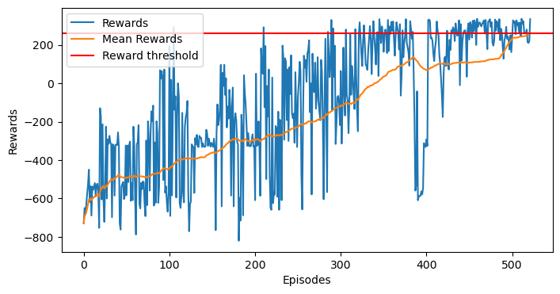

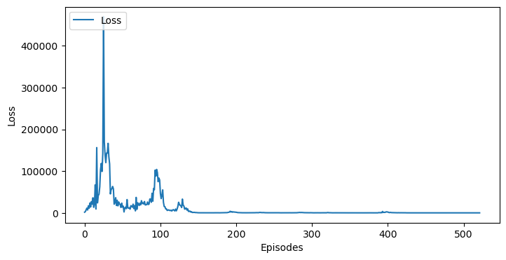

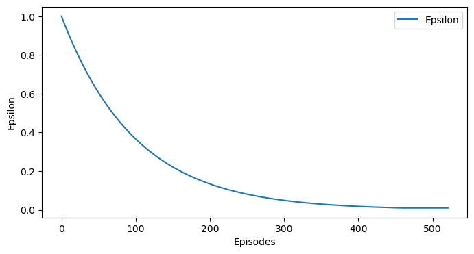

```python
plot_rewards(agentDQN.training_rewards,agentDQN.mean_training_rewards,REWARD_THRESHOLD)
plot_loss(agentDQN.training_loss)
plot_epsilon(agentDQN.epsilon_evolution)
```

Una vez entrenado el agente, nos interesa comprobar cómo de bien ha aprendido y si es capaz de conseguir que el coche llegue a su objetivo. Para ello, recuperamos el modelo entrenado y dejamos que el agente tome acciones aleatorias según ese modelo y observamos su comportamiento.

**Ejercicio (0.5 ptos):** Cargar el modelo entrenado y ejecutar el agente entrenado durante 100 episodios consecutivos. Calcula la suma de recompensas por cada episodio. Mostrar:

- Un gráfico con la suma de las recompensas respecto de los episodios, incluyendo el umbral de recompensa establecido
- Reproducir una partida del agente generado.
- Almacena la recompensa media obtenida en las 100 partidas en la variable **mean_reward_dqn**

Comentar los resultados obtenidos. --------------------------------------------------------------------------------------------------- *Opcional*: visualizar los episodios con `env.render()`

```python
torch.save(agentDQN.main_network.state_dict(), 'DQN_ENTRENADO.pth')
model_path = 'DQN_ENTRENADO.pth'
agentDQN.main_network.load_state_dict(torch.load(model_path))
agentDQN.target_network.load_state_dict(agentDQN.main_network.state_dict(),strict=False)
```

```
<All keys matched successfully>
```

```
Recompensa media en 100 episodios: 258.8
```

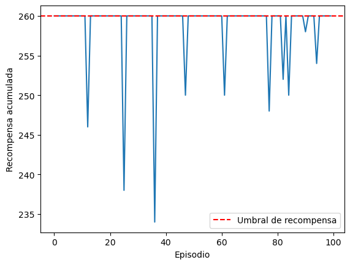

```python
import matplotlib.pyplot as plt

# Ejecutar el agente durante 100 episodios
num_episodes = 100
episode_rewards = []

for episode in range(num_episodes):
    state = env.reset()[0]
    total_reward = 0

    while True:
        action = agentDQN.main_network.get_action(state, epsilon=0)  # Epsilon 0 para acciones determinísticas
        next_state, reward, terminated, truncated, _ = env.step(action)

        total_reward += reward

        if terminated or truncated or total_reward == 260:
            break

        state = next_state

    episode_rewards.append(total_reward)

# Calcula la recompensa media
mean_reward_dqn = sum(episode_rewards) / num_episodes
print("Recompensa media en 100 episodios:", mean_reward_dqn)

# Visualizar el gráfico de recompensas por episodio
plt.plot(episode_rewards)
plt.axhline(y=REWARD_THRESHOLD, color='r', linestyle='--', label='Umbral de recompensa')
plt.xlabel('Episodio')
plt.ylabel('Recompensa acumulada')
plt.legend()
plt.show()
```

**Comentarios: Podemos observar como en la mayoria de los casos se alcanza el objetivo de 260 de recompensa, aunque existe una pequeña probabilidad de que el agente se equivoque.**

### 3. Agente noisy DQN ( 1.5 ptos)

Ahora vamos a modificar la DQN implementada y, simplemente añadiremos algo de ruido a los pesos y sesgos de las capas de la red neuronal. Entre los dos tipos de ruidos propuestos en la teoría, implementaremos el siguiente:

**Ruido Gaussiano:** El ruido aplicado a cada peso y sesgo es independiente, donde cada entrada $\epsilon^{w}_{i,j}$ (respectivamente, cada entrada $\epsilon^{b}_{j}$) de la matriz aleatoria $\epsilon^{w}$ (respectivamente, del vector aleatorio $\epsilon^{b}$) se obtiene de una distribución Gaussiana estándar. Esto significa que para cada capa lineal ruidosa, hay pq + q variables de ruido (para p entradas a la capa y q salidas).

```python
class NoisyLinear(torch.nn.Linear):
    def __init__(self, in_features, out_features,
                 sigma_init=0.017, bias=True):
        super().__init__(in_features, out_features, bias=bias)
        w = torch.full((out_features, in_features), sigma_init)
        self.sigma_weight = torch.nn.Parameter(w)
        z = torch.zeros(out_features, in_features)
        self.register_buffer("epsilon_weight", z)
        if bias:
            w = torch.full((out_features,), sigma_init)
            self.sigma_bias = torch.nn.Parameter(w)
            z = torch.zeros(out_features)
            self.register_buffer("epsilon_bias", z)
        self.reset_parameters()

    def reset_parameters(self):
        std = math.sqrt(3 / self.in_features)
        self.weight.data.uniform_(-std, std)
        self.bias.data.uniform_(-std, std)

    def forward(self, input):
        self.epsilon_weight.normal_()
        bias = self.bias
        if bias is not None:
            self.epsilon_bias.normal_()
            bias = bias + self.sigma_bias * \
                   self.epsilon_bias.data
        v = self.sigma_weight * self.epsilon_weight.data + \
            self.weight
        return F.linear(input, v, bias)
```

**Ejercicio (1 pto):** Utilizando la implementación anterior, modifica la clase `NeuralNetControlSpeed()` para crear la clase `NoisyNetControlCar()` con la siguiente configuración:

- Un capa completamente conectada (representadas en pytorch por nn.Lineal) con 128 neuronas y bias=True, y activación ReLU.
- Un capa completamente conectada NoisyLinear con 64 neuronas y bias=True, y activación ReLU.
- Una capa de salida completamente conectada y bias=True

```python
class NoisyNetControlCar(torch.nn.Module):

    ###################################
    ###inicialización y modelo###
    def __init__(self, env, learning_rate=1e-3):

        """
        Params
        ======
        n_inputs: tamaño del espacio de estadps
        n_outputs: tamaño del espacio de acciones
        actions: array de acciones posibles
        """
        super(NoisyNetControlCar, self).__init__()
        self.n_inputs = env.observation_space.shape[0]
        self.n_outputs = env.action_space.n
        self.actions = np.arange(env.action_space.n)
        self.learning_rate = learning_rate


        #######################################
        ##Construcción de la red neuronal
        self.model = torch.nn.Sequential(
            torch.nn.Linear(self.n_inputs, 128),
            torch.nn.ReLU(),
            NoisyLinear(128, 64, sigma_init = learning_rate),
            torch.nn.ReLU(),
            torch.nn.Linear(64, self.n_outputs, bias=True))


        #######################################
        ##Inicializar el optimizador
        self.optimizer = torch.optim.Adam(self.model.parameters(), lr=self.learning_rate)


    ### Método e-greedy
    def get_action(self, state, epsilon=0.05):
        if np.random.random() < epsilon:
            action = np.random.choice(self.actions)  # acción aleatoria
        else:
            qvals = self.get_qvals(state)  # acción a partir del cálculo del valor de Q para esa acción
            action= torch.max(qvals, dim=-1)[1].item()
        return action

    def get_qvals(self, state):
        if type(state) is tuple:
            state = np.array([np.ravel(s) for s in state])
        else:
            state = [state]
        state_t = torch.FloatTensor(state)
        return self.model(state_t)
```

```python
class DQNAgent_Noisy:
    def __init__(self, env, main_network, buffer, epsilon=0.1, eps_decay=0.99, batch_size=32):

        ######################################
        ##TODO 1: Declarar variables
        self.env = env
        self.main_network = main_network
        self.target_network = deepcopy(self.main_network)
        self.buffer = buffer
        self.epsilon = epsilon
        self.eps_decay = eps_decay
        self.batch_size = batch_size
        self.nblock = 100 # bloque de los X últimos episodios de los que se calculará la media de recompensas
        self.initialize()


    def initialize(self):
        self.update_loss = []
        self.training_loss = []
        self.training_rewards = []
        self.mean_training_rewards = []
        self.sync_eps = []
        self.total_reward = 0
        self.step_count = 0
        self.state0 = self.env.reset()[0]
        self.car_game_state = []
        self.epsilon_evolution = []


    ######################################
    ##TODO 3: Tomar paso siguiente
    def take_step(self, eps, mode='train'):
        if mode == 'explore':
            action = random.choice(self.main_network.actions)  # acción aleatoria en el burn-in
        else:
            action = self.main_network.get_action(self.state0, epsilon=eps) # acción a partir del valor de Q (elección de la acción con mejor Q)

        self.step_count += 1

        #TODO: tomar 'step' i obtener nuevo estado y recompensa. Guardar la experiencia en el buffer

        next_state, reward, terminated, truncated, _ = self.env.step(action)

        done = terminated or truncated
        self.total_reward += reward
        self.buffer.append(self.state0, action, reward, done, next_state)

        #TODO: resetear entorno 'if done'

        if done:
            self.state0 = self.env.reset()[0]
        else:
            self.state0 = next_state

        return done


    ## Entrenamiento
    def train(self, gamma=0.99, max_episodes=50000,
              batch_size=32,
              dnn_update_frequency=4,
              dnn_sync_frequency=2000, REWARD_THRESHOLD = 260):


        self.gamma = gamma

        # Rellenamos el buffer con N experiencias aleatorias ()
        print("Filling replay buffer...")
        while self.buffer.burn_in_capacity() < 1:
            self.take_step(self.epsilon, mode='explore')


        episode = 0
        training = True
        print("Training...")
        while training:
            self.state0 = self.env.reset()[0]
            self.total_reward = 0
            gamedone = False
            while gamedone == False:
                # El agente toma una acción
                gamedone = self.take_step(self.epsilon, mode='train')



                #################################################################################
                #####TODO 4:  Actualizar la red principal según la frecuencia establecida #######
                if self.step_count % dnn_update_frequency == 0:
                    self.update()



                ########################################################################################
                ###TODO 6: Sincronizar red principal y red objetivo según la frecuencia establecida#####
                if self.step_count % dnn_sync_frequency == 0:
                  self.target_network.load_state_dict(self.main_network.state_dict(), strict=False)

                if gamedone:
                    episode += 1
                    self.episodes_train_noisy = episode
                    self.training_loss.append(np.mean(self.update_loss))
                    self.epsilon_evolution.append(self.epsilon)

                    self.update_loss = []

                    #######################################################################################
                    ###TODO 7: calcular la media de recompensa de los últimos X episodios, y almacenar#####

                    self.training_rewards.append(self.total_reward)
                    mean_rewards = np.mean(self.training_rewards[-self.nblock:])
                    self.mean_training_rewards.append(mean_rewards)

                    #######################################################################################
                    ### TODO 8: Comprobar que todavía quedan episodios. Parar el aprendizaje si se llega al límite


                    print("\rEpisode {:d} Mean Rewards {:.2f} Epsilon {}\t\t".format(
                        episode, mean_rewards, self.epsilon), end="")

                    # Comprobamos que todavía quedan episodios
                    if episode >= max_episodes:
                        training = False
                        print('\nEpisode limit reached.')
                        print('\nEnvironment solved in {} episodes!'.format(
                            episode))
                        break

                    if mean_rewards >= REWARD_THRESHOLD:
                        training = False
                        print('\nEpisode limit reached.')
                        print('\nEnvironment solved in {} episodes!'.format(
                            episode))
                        break


                    #################################################################################
                    ######TODO 9: Actualizar epsilon según la velocidad de decaimiento fijada########
                    self.epsilon = max(self.epsilon * self.eps_decay, 0.01)


    ## Cálculo de la pérdida
    def calculate_loss(self, batch):
      #  print('loss')
        # Separamos las variables de la experiencia y las convertimos a tensores
        states, actions, rewards, dones, next_states = [i for i in batch]
        rewards_vals = torch.FloatTensor(rewards)
        actions_vals = torch.LongTensor(np.array(actions)).reshape(-1,1)
        dones_t = torch.BoolTensor(dones)
        # Obtenemos los valores de Q de la red principal
        qvals = torch.gather(self.main_network.get_qvals(states), 1, actions_vals)
        # Obtenemos los valores de Q objetivo. El parámetro detach() evita que estos valores actualicen la red objetivo
        qvals_next = torch.max(self.target_network.get_qvals(next_states),
                               dim=-1)[0].detach()
        qvals_next[dones_t] = 0 # 0 en estados terminales

        #################################################################################
        ### TODO: Calcular ecuación de Bellman
        expected_qvals = self.gamma * qvals_next + rewards_vals

        #################################################################################
        ### TODO: Calcular la pérdida (MSE)
        loss = torch.nn.MSELoss()(qvals, expected_qvals.reshape(-1,1))

        return loss



    def update(self):
        self.main_network.optimizer.zero_grad()  # eliminamos cualquier gradiente pasado
        batch = self.buffer.sample_batch(batch_size=self.batch_size) # seleccionamos un conjunto del buffer
        loss = self.calculate_loss(batch) # calculamos la pérdida
        loss.backward() # hacemos la diferencia para obtener los gradientes
        self.main_network.optimizer.step() # aplicamos los gradientes a la red neuronal
        # Guardamos los valores de pérdida
        self.update_loss.append(loss.detach().numpy())
```

**Ejercicio (0.25 ptos):** Entrena el agente y representar:

1. Gráfico con las recompensas obtenidas a lo largo del entrenamieno, la evolución de las recompensas medias cada 100 episodios, y el umbral de recompensa establecido por el entorno.
2. Gráfico con la evolución de la perdida a lo largo del entrenamiento
3. Gráfico con la evolución de epsilon a lo largo del entrenamiento
4. Almacena la cantidad de episodios necesarios para llevar acabo el entrenamiento en la variable episodes_train_noisy

Comentar los resultados obtenidos.

```python
buffer = experienceReplayBuffer(memory_size=MEMORY_SIZE, burn_in=BURN_IN)
noisy_agent = NoisyNetControlCar(env, learning_rate=lr)
agentDQN_noisy = DQNAgent_Noisy(env, noisy_agent, buffer, EPSILON, EPSILON_DECAY, BATCH_SIZE)


start_time = time.time()

agentDQN_noisy.train(gamma=GAMMA, max_episodes=MAX_EPISODES,
              batch_size=BATCH_SIZE, dnn_update_frequency=DNN_UPD, dnn_sync_frequency=DNN_SYNC)

episodes_train_noisy = agentDQN_noisy.episodes_train_noisy


end_time = time.time()
print('Training time: ' + str(round((end_time-start_time)/60,2)) + " minutes")
```

```
Filling replay buffer...
Training...
Episode 823 Mean Rewards 266.80 Epsilon 0.01		118606165716
Episode limit reached.

Environment solved in 823 episodes!
Training time: 4.13 minutes
```

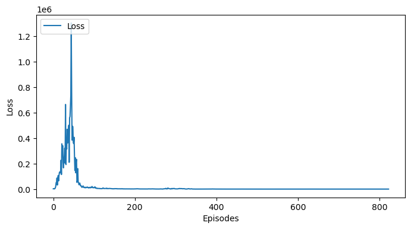

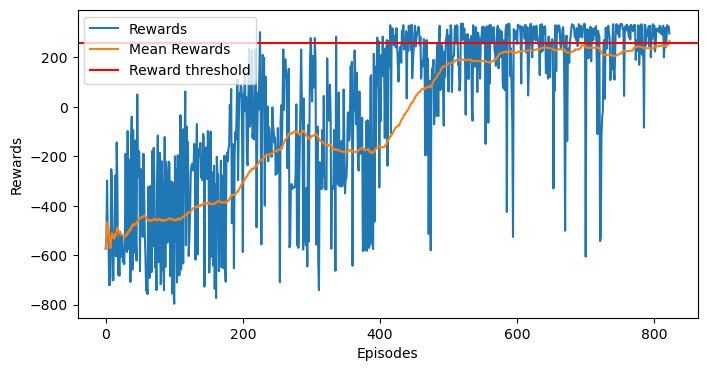

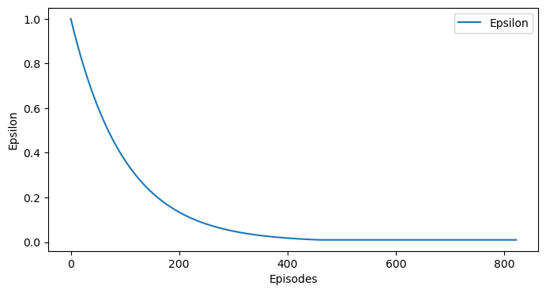

```python
plot_loss(agentDQN_noisy.training_loss)
plot_rewards(agentDQN_noisy.training_rewards,agentDQN_noisy.mean_training_rewards,REWARD_THRESHOLD)
plot_epsilon(agentDQN_noisy.epsilon_evolution)
```

**Ejercicio (0.25 ptos):** Ejecutar el agente entrenado durante 100 episodios consecutivos. Calcula la suma de recompensas por cada episodio. Mostrar:

- Un gráfico con la suma de las recompensas respecto de los episodios, incluyendo el umbral de recompensa establecido por el entorno
- Reproducir una partida del agente generado.
- Almacena la recompensa media obtenida en las 100 partidas en la variable mean_reward_noisy

Comentar los resultados obtenidos.

```python
torch.save(agentDQN_noisy.main_network.state_dict(), 'DQN_NOISY_ENTRENADO.pth')
model_path = 'DQN_NOISY_ENTRENADO.pth'
agentDQN_noisy.main_network.load_state_dict(torch.load(model_path))
agentDQN_noisy.target_network.load_state_dict(agentDQN_noisy.main_network.state_dict(),strict=False)
```

```
<All keys matched successfully>
```

```
Recompensa media en 100 episodios: 259.92
```

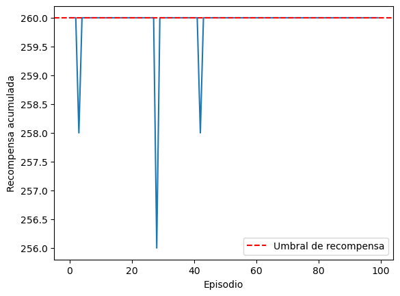

```python
# Ejecutar el agente durante 100 episodios
num_episodes = 100
episode_rewards = []

for episode in range(num_episodes):
    state = env.reset()[0]
    total_reward = 0

    while True:
        action = agentDQN_noisy.main_network.get_action(state, epsilon=0)
        next_state, reward, terminated, truncated, _ = env.step(action)

        total_reward += reward

        if terminated or truncated or total_reward == 260:
            break

        state = next_state

    episode_rewards.append(total_reward)

# Calcula la recompensa media
mean_reward_noisy = sum(episode_rewards) / num_episodes
print("Recompensa media en 100 episodios:", mean_reward_noisy)

# Visualizar el gráfico de recompensas por episodio
plt.plot(episode_rewards)
plt.axhline(y=REWARD_THRESHOLD, color='r', linestyle='--', label='Umbral de recompensa')
plt.xlabel('Episodio')
plt.ylabel('Recompensa acumulada')
plt.legend()
plt.show()
```

**Comentarios: Podemos observar como en la mayoria de los casos se alcanza el objetivo de 260 de recompensa, aunque existe una pequeña probabilidad de que el agente se equivoque aunque menor al DQN normal.**

### 4. Agente doble DQN (2.5 ptos)

En este apartado implementaremos una doble DQN con la misma red neuronal y características de la DQN del apartado anterior.

Recordemos que con la doble DQN, es la red principal la que elije la acción con mayor valor de Q, y la red objetivo la que proporciona el valor objetivo de Q para esa acción, es decir, la que dirá qué recompensa tiene esa acción elegida por la red principal.

Siguiendo el mismo esquema que en el ejercicio anterior, a continuación implementaremos una clase que defina el entrenamiento del agente teniendo en cuenta:

- La exploración/explotación (decaimiento de epsilon)
- La actualización y sincronización de la red principal y la red objetivo (pérdida)

**Ejercicio (1 pto):** Implementar los siguientes puntos de la clase `DDQNAgent()`siguiendo el mismo esquema de implementación realizado con el método `DQNAgent()`

```python
class DDQNAgent:
    def __init__(self, env, main_network, buffer, epsilon=0.1, eps_decay=0.99, batch_size=32):
        self.env = env
        self.main_network = main_network
        self.target_network = deepcopy(self.main_network)
        self.buffer = buffer
        self.epsilon = epsilon
        self.eps_decay = eps_decay
        self.batch_size = batch_size
        self.nblock = 100
        self.initialize()

    def initialize(self):
        self.update_loss = []
        self.training_loss = []
        self.training_rewards = []
        self.mean_training_rewards = []
        self.sync_eps = []
        self.total_reward = 0
        self.step_count = 0
        self.state0 = self.env.reset()[0]
        self.car_game_state = []
        self.epsilon_evolution = []

    def take_step(self, eps, mode='train'):
        if mode == 'explore':
            #action = self.main_network.get_action(self.state0, epsilon=1)  # acción aleatoria en el burn-in
            action = random.choice(self.main_network.actions)
        else:
            action = self.main_network.get_action(self.state0, epsilon=eps) # acción a partir del valor de Q (elección de la acción con mejor Q)

        self.step_count += 1 # Se actualiza el conteo de steps

        #TODO: tomar 'step' i obtener nuevo estado y recompensa. Guardar la experiencia en el buffer
        next_state, reward, terminated, truncated, _ = self.env.step(action)

        done = terminated or truncated

        self.total_reward += reward

        self.buffer.append(self.state0, action, reward, done, next_state)

        #TODO: resetear entorno 'if done'
        if done:
            self.state0 = self.env.reset()[0]
        else:
            self.state0 = next_state

        return done

    ## Entrenamiento
    def train(self, gamma=0.99, max_episodes=50000,
              batch_size=32,
              dnn_update_frequency=4,
              dnn_sync_frequency=2000, REWARD_THRESHOLD = 260):

        self.gamma = gamma

        mean_rewards = 0

        # Rellenamos el buffer con N experiencias aleatorias ()
        print("Filling replay buffer...")
        while self.buffer.burn_in_capacity() < 1:
            self.take_step(self.epsilon, mode='explore')

        episode = 0
        training = True
        print("Training...")
        self.episodes_train_double = episode

        while training:
            self.state0 = self.env.reset()[0]
            self.total_reward = 0
            gamedone = False
            while gamedone == False:
                # El agente toma una acción
                gamedone = self.take_step(self.epsilon, mode='train')

                #################################################################################
                #####TODO 4:  Actualizar la red principal según la frecuencia establecida #######
                #print(f"step_count / update_freq: {self.step_count % dnn_update_frequency}")
                if self.step_count % dnn_update_frequency == 0:
                    self.update()

                ########################################################################################
                ###TODO 6: Sincronizar red principal y red objetivo según la frecuencia establecida#####
                if self.step_count % dnn_sync_frequency == 0:
                    # Cargar el estado filtrado en el modelo objetivo
                    self.target_network.load_state_dict(self.main_network.state_dict(), strict=False)


                if gamedone:
                    episode += 1
                    self.episodes_train_double = episode

                    self.training_loss.append(np.mean(self.update_loss))
                    self.epsilon_evolution.append(self.epsilon)

                    self.update_loss = []

                    #######################################################################################
                    ###TODO 7: calcular la media de recompensa de los últimos X episodios, y almacenar#####
                    self.training_rewards.append(self.total_reward)
                    mean_rewards = np.mean(self.training_rewards[-self.nblock:])
                    self.mean_training_rewards.append(mean_rewards)

                    #######################################################################################
                    ### TODO 8: Comprobar que todavía quedan episodios. Parar el aprendizaje si se llega al límite


                    print("\rEpisode {:d} Mean Rewards {:.2f} Epsilon {}\t\t".format(
                        episode, mean_rewards, self.epsilon), end="")

                    # Comprobamos que todavía quedan episodios
                    if episode >= max_episodes:
                        training = False
                        print('\nEpisode limit reached.')
                        print('\nEnvironment solved in {} episodes!'.format(
                            episode))
                        break

                    if mean_rewards >= REWARD_THRESHOLD:
                        training = False
                        print('\nEpisode limit reached.')
                        print('\nEnvironment solved in {} episodes!'.format(
                            episode))
                        break

                    #################################################################################
                    ######TODO 9: Actualizar epsilon según la velocidad de decaimiento fijada########
                    self.epsilon = max(self.epsilon * self.eps_decay, 0.01) # Así se evita que epsilon caiga demasiado

                    break

    def calculate_loss(self, batch):
        states, actions, rewards, dones, next_states = [i for i in batch]

        rewards_vals = torch.FloatTensor(rewards).to(device=self.main_network.device)
        actions_vals = torch.LongTensor(np.array(actions)).reshape(-1,1).to(device=self.main_network.device)
        dones_t = torch.BoolTensor(dones).to(device=self.main_network.device)

        qvals = torch.gather(self.main_network.get_qvals(states), 1, actions_vals)

        # Modificaciones clave para doble DQN empiezan aquí
        next_actions = torch.argmax(self.main_network.get_qvals(next_states), dim=1)
        qvals_next = torch.gather(self.target_network.get_qvals(next_states), 1, next_actions.unsqueeze(-1)).squeeze(-1)
        qvals_next[dones_t] = 0

        expected_qvals = rewards_vals + self.gamma * qvals_next
        loss = torch.nn.MSELoss()(qvals, expected_qvals.unsqueeze(1))
        return loss

    def update(self):
        self.main_network.optimizer.zero_grad()
        batch = self.buffer.sample_batch(batch_size=self.batch_size)
        loss = self.calculate_loss(batch)
        loss.backward()
        self.main_network.optimizer.step()
        if self.main_network.device == 'cuda':
            self.update_loss.append(loss.detach().cpu().numpy())
        else:
            self.update_loss.append(loss.detach().numpy())
```

A continuación entrenaremos el modelo con los mismos hiperparámetros que con la DQN.

**Ejercicio (0.5 ptos):** Entrenar el agente.

```python
buffer = experienceReplayBuffer(memory_size=MEMORY_SIZE, burn_in=BURN_IN)
device = "cuda" if torch.cuda.is_available() else "cpu"
neural_net = NeuralNetControlSpeed(env, learning_rate=lr, device = device)
agentDDQN = DDQNAgent(env, neural_net, buffer, EPSILON, EPSILON_DECAY, BATCH_SIZE)


start_time = time.time()

agentDDQN.train(gamma=GAMMA, max_episodes=MAX_EPISODES,
              batch_size=BATCH_SIZE, dnn_update_frequency=DNN_UPD, dnn_sync_frequency=DNN_SYNC)


episodes_train_double = agentDDQN.episodes_train_double

print(f'Número de episodios entrenados: {episodes_train_double}')

end_time = time.time()

print('Training time: ' + str(round((end_time-start_time)/60,2)) + " minutes")
```

```
Filling replay buffer...
Training...
Episode 386 Mean Rewards 263.93 Epsilon 0.020871320158888425
Episode limit reached.

Environment solved in 386 episodes!
Número de episodios entrenados: 386
Training time: 1.35 minutes
```

**Ejercicio (0.5 ptos):** Representar:

1. Gráfico con las recompensas obtenidas a lo largo del entrenamieno, la evolución de las recompensas medias cada 100 episodios, y el umbral de recompensa establecido por el entorno
2. Gráfico con la posición final del coche en cada episodio
3. Gráfico con la evolución de la perdida a lo largo del entrenamiento
4. Gráfico con la evolución de epsilon a lo largo del entrenamiento

Comentar los resultados obtenidos.

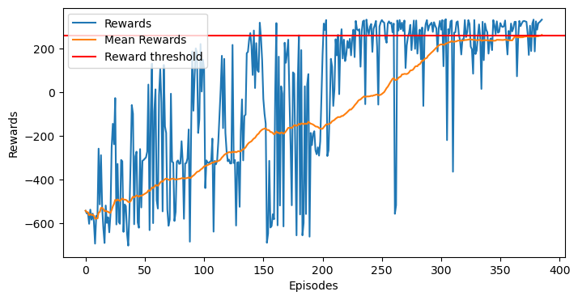

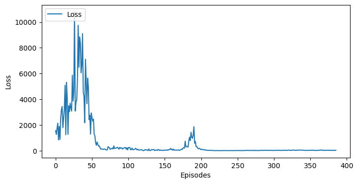

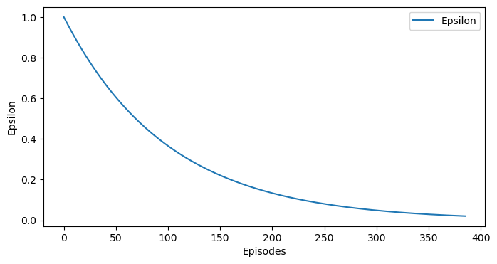

```python
plot_rewards(agentDDQN.training_rewards,agentDDQN.mean_training_rewards,REWARD_THRESHOLD)
plot_loss(agentDDQN.training_loss)
plot_epsilon(agentDDQN.epsilon_evolution)
```

**Solución: En este caso, las recompensas medias oscilan bastante hasta el episodio 200, donde se mantiene la oscilación equilibrada entre el valor objetivo. En la pérdida se observa que no se llega al 0 definitivamente hasta el episodio 200. El decaimiento no llega a aplanarse y se corta al terminar el entrenamiento sin llegar a un mínimo visible.**

**Ejercicio (0.5 ptos):** Ejecuta el agente entrenado durante 100 episodios consecutivos. Calcular la suma de recompensas por cada episodio. Mostrar:

- un gráfico con la suma de las recompensas respecto de los episodios, incluyendo el umbral de recompensa establecido por el entorno
- Almacena la media de las recompensas en mean_reward_double

Comentar los resultados obtenidos. --------------------------------------------------------------------------------------------------- *Opcional*: visualizar los episodios con `env.render()`, sólo posible en local. Esta visualización ralentiza el proceso unos segundos por episodio.

```python
torch.save(agentDDQN.main_network.state_dict(), 'modelo_ddqn.pth')
model_path = 'modelo_ddqn.pth'
agentDDQN.main_network.load_state_dict(torch.load(model_path))
agentDDQN.target_network.load_state_dict(agentDDQN.main_network.state_dict(),
                                           strict=False)
```

```
<All keys matched successfully>
```

```
Recompensa media en 100 episodios: 260.0
```

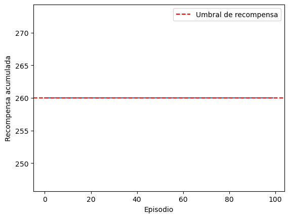

```python
num_episodes = 100
episode_rewards = []

for episode in range(num_episodes):
    state = env.reset()[0]
    total_reward = 0

    while True:
        action = agentDDQN.main_network.get_action(state, epsilon=0)
        next_state, reward, terminated, truncated, _ = env.step(action)

        total_reward += reward

        if terminated or truncated or total_reward == 260:
            break

        state = next_state

    episode_rewards.append(total_reward)

# Se calcula la recompensa media para los 100 episodios:

mean_reward_double = sum(episode_rewards) / num_episodes
print("Recompensa media en 100 episodios:", mean_reward_double)

# Visualizo el gráfico de recompensas por episodio:

plt.plot(episode_rewards)
plt.axhline(y=REWARD_THRESHOLD, color='r', linestyle='--', label='Umbral de recompensa')
plt.xlabel('Episodio')
plt.ylabel('Recompensa acumulada')
plt.legend()
plt.show()
```

**Comentario:** En este caso se llega al objetivo de 260 de rempensa el 100 % de los episodios.

Ahora vamos a comparar los resultados, si has seguido todas las indicaciones, habrás almacenado métricas bastante interesantes que te permitirán interpretar los resultados obtenidos.

```python
# Define los datos de la tabla
data = [
    ["DQN", episodes_train_dqn, mean_reward_dqn],
    ["Noisy DQN", episodes_train_noisy, mean_reward_noisy],
    ["Double DQN", episodes_train_double, mean_reward_double]
]

# Define los encabezados de la tabla
headers = ["Agente", "Episodios de Entrenamiento", "Media test con 100 Partidas"]

# Imprime la tabla
table = tabulate(data, headers, tablefmt="pipe")
print(table)
```

```
| Agente     |   Episodios de Entrenamiento |   Media test con 100 Partidas |
|:-----------|-----------------------------:|------------------------------:|
| DQN        |                          522 |                        258.8  |
| Noisy DQN  |                          823 |                        259.92 |
| Double DQN |                          386 |                        260    |
```

**Ejercicio (0.5 ptos):** Comentar los resultados obtenidos. ¿Qué agente a obtenido mejor resultados?

**Comentario:** Observando los resultados obtenidos de los algoritmos entrenados podemos ver que el mejor tiempo y el mejor resultado o el mas robustos es el double DQN. De la misma manera el DQN tarda menos episodios de entrenamientos que el DQN noisy para llegar al objetivo pero no llega al 100% de acierto en la ejecucion. De la misma manera, el DQN noisy es el que mas tarde en comparacion que los demas pero mantiene un indice de aciertos mayor que el DQN normal.

### Compara los agentes en otro entorno. (2.5 ptos)

En esta parte de la PEC vamos a comparar cómo se desenvuelven dichos agentes en otro entorno diferente implementado por un tercero.

Uno de los beneficios de haber utilizado Gymnasium es que podemos rápidamente utilizar nuestros algoritmos en todo aquel entorno que comparta la misma interfaz. Un ejemplo puede se [Mountain Car](https://gymnasium.farama.org/environments/classic_control/mountain_car/), un juego muy básico que consiste en un automóvil ubicado de manera estocástica en la parte inferior de un valle sinusoidal, con las únicas acciones posibles siendo las aceleraciones que se pueden aplicar al automóvil en cualquier dirección.

[figure not shown]

**Ejercicio (2,5 ptos):** Adapta los hiperparámetros según te convenga para entrenar los diferentes agentes en el nuevo entorno. Una vez lo hayar realizado, implementar una tabla como la mostrar en el ejercico anterior y análiza los resultados. Para ello, entrena cada agente y almacena en episodes_train cuantos episodios han sido necesarios para el agente vencer al entorno. Posteriormente, ejecuta cada agente entrenado durante 100 episodios consecutivos. Calcular la suma de recompensas por cada episodio y muestra un gráfico con la suma de las recompensas respecto de los episodios, incluyendo el umbral de recompensa establecido por el entorno. Almacena cada media de las recompensas en mean_reward correspondiente.  
¿Contínua siendo el mismo agente el que mejor resultado ha obtenido?

```python
import gymnasium as gym
env = gym.make('MountainCar-v0')

lr = 0.001      #TODO
MEMORY_SIZE = 10000   #Máxima capacidad del buffer 10000
MAX_EPISODES = 3000   #Número máximo de episodios (el agente debe aprender antes de llegar a este valor)
EPSILON = 1           #Valor inicial de epsilon
EPSILON_DECAY = .99   #Decaimiento de epsilon 0.009
GAMMA = 0.99          #Valor gamma de la ecuación de Bellman
BATCH_SIZE = 32       #Conjunto a coger del buffer para la red neuronal
BURN_IN = 1000        #Número de experiencias iniciales usadas para rellenar el buffer antes de entrenar
DNN_UPD = 1          #TODO [1-10]
DNN_SYNC = 10       #TODO  [10 - 100]
```

```python
buffer = experienceReplayBuffer(memory_size=MEMORY_SIZE, burn_in=BURN_IN)
device = "cuda" if torch.cuda.is_available() else "cpu"
neural_net = NeuralNetControlSpeed(env, learning_rate=lr, device = device)
agentDQN_Mountain = DQNAgent_Mountain(env, neural_net, buffer, EPSILON, EPSILON_DECAY, BATCH_SIZE)

start_time = time.time()

agentDQN_Mountain.train(gamma=GAMMA, max_episodes=MAX_EPISODES,
              batch_size=BATCH_SIZE, dnn_update_frequency=DNN_UPD, dnn_sync_frequency=DNN_SYNC,
              REWARD_THRESHOLD = -110)

episodes_train_dqn = agentDQN_Mountain.episodes_train_dqn

end_time = time.time()

print('tiempo de entreno: ' + str(round((end_time-start_time)/60,2)) + " minutos")
```

```
Filling replay buffer...
Training...
Episode 1152 Mean Rewards -110.00 Epsilon 0.01		118606165716
Episode limit reached.

Environment solved in 1152 episodes!
tiempo de entreno: 1.69 minutos
```

```python
env.action_space
```

```
Discrete(3)
```

```python
torch.save(agentDQN_Mountain.main_network.state_dict(), 'DQN_ENTRENADO_mountain.pth')
model_path = 'DQN_ENTRENADO_mountain.pth'
agentDQN_Mountain.main_network.load_state_dict(torch.load(model_path))
agentDQN_Mountain.target_network.load_state_dict(agentDQN_Mountain.main_network.state_dict(),strict=False)
```

```
<All keys matched successfully>
```

```
Recompensa media en 100 episodios: -100.4
```

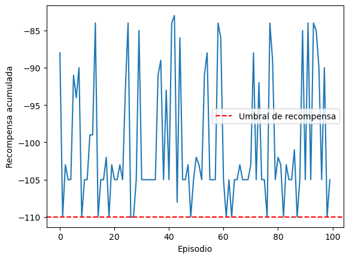

```python
num_episodes = 100
episode_rewards = []

for episode in range(num_episodes):
    state = env.reset()[0]
    total_reward = 0

    while True:
        action = agentDQN.main_network.get_action(state, epsilon=0)
        next_state, reward, terminated, truncated, _ = env.step(action)

        total_reward += reward

        if terminated or truncated or total_reward == -110:
            break

        state = next_state

    episode_rewards.append(total_reward)

# Se calcula la recompensa media para los 100 episodios:

mean_reward_dqn = sum(episode_rewards) / num_episodes
print("Recompensa media en 100 episodios:", mean_reward_dqn)

# Visualizo el gráfico de recompensas por episodio:

plt.plot(episode_rewards)
plt.axhline(y=-110, color='r', linestyle='--', label='Umbral de recompensa')
plt.xlabel('Episodio')
plt.ylabel('Recompensa acumulada')
plt.legend()
plt.show()
```

```python
buffer = experienceReplayBuffer(memory_size=MEMORY_SIZE, burn_in=BURN_IN)
noisy_agent = NoisyNetControlCar(env, learning_rate=lr)
agentDQN_noisy = DQNAgent_Noisy(env, noisy_agent, buffer, EPSILON, EPSILON_DECAY, BATCH_SIZE)


start_time = time.time()

agentDQN_noisy.train(gamma=GAMMA, max_episodes=MAX_EPISODES,
              batch_size=BATCH_SIZE, dnn_update_frequency=DNN_UPD, dnn_sync_frequency=DNN_SYNC,
                    REWARD_THRESHOLD = -110)

episodes_train_noisy = agentDQN_noisy.episodes_train_noisy


end_time = time.time()
print('Training time: ' + str(round((end_time-start_time)/60,2)) + " minutes")
```

```
Filling replay buffer...
Training...
Episode 2596 Mean Rewards -109.62 Epsilon 0.01		118606165716
Episode limit reached.

Environment solved in 2596 episodes!
Training time: 6.23 minutes
```

```python
torch.save(agentDQN_noisy.main_network.state_dict(), 'DQN_NOISY_ENTRENADO.pth')
model_path = 'DQN_NOISY_ENTRENADO.pth'
agentDQN_noisy.main_network.load_state_dict(torch.load(model_path))
agentDQN_noisy.target_network.load_state_dict(agentDQN_noisy.main_network.state_dict(),strict=False)
```

```
<All keys matched successfully>
```

```
Recompensa media en 100 episodios: -100.74
```

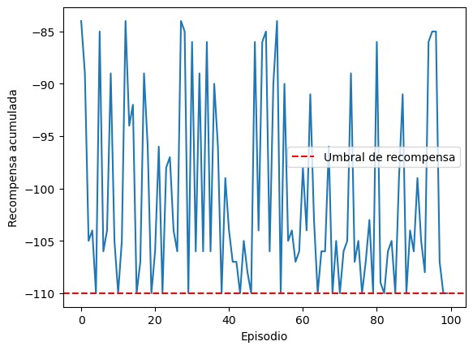

```python
num_episodes = 100
episode_rewards = []

for episode in range(num_episodes):
    state = env.reset()[0]
    total_reward = 0

    while True:
        action = agentDQN_noisy.main_network.get_action(state, epsilon=0)
        next_state, reward, terminated, truncated, _ = env.step(action)

        total_reward += reward

        if terminated or truncated or total_reward == -110:
            break

        state = next_state

    episode_rewards.append(total_reward)

# Se calcula la recompensa media para los 100 episodios:

mean_reward_noisy = sum(episode_rewards) / num_episodes
print("Recompensa media en 100 episodios:", mean_reward_noisy)

# Visualizo el gráfico de recompensas por episodio:

plt.plot(episode_rewards)
plt.axhline(y=-110, color='r', linestyle='--', label='Umbral de recompensa')
plt.xlabel('Episodio')
plt.ylabel('Recompensa acumulada')
plt.legend()
plt.show()
```

```python
buffer = experienceReplayBuffer(memory_size=MEMORY_SIZE, burn_in=BURN_IN)
device = "cuda" if torch.cuda.is_available() else "cpu"
neural_net = NeuralNetControlSpeed(env, learning_rate=lr, device = device)
agentDDQN = DDQNAgent(env, neural_net, buffer, EPSILON, EPSILON_DECAY, BATCH_SIZE)


start_time = time.time()

agentDDQN.train(gamma=GAMMA, max_episodes=MAX_EPISODES,
              batch_size=BATCH_SIZE, dnn_update_frequency=DNN_UPD, dnn_sync_frequency=DNN_SYNC,
                REWARD_THRESHOLD = -110)


episodes_train_double = agentDDQN.episodes_train_double

print(f'Número de episodios entrenados: {episodes_train_double}')

end_time = time.time()

print('Training time: ' + str(round((end_time-start_time)/60,2)) + " minutes")
```

```
Filling replay buffer...
Training...
Episode 1817 Mean Rewards -109.99 Epsilon 0.01		118606165716
Episode limit reached.

Environment solved in 1817 episodes!
Número de episodios entrenados: 1817
Training time: 2.96 minutes
```

```
Recompensa media en 100 episodios: -102.25
```

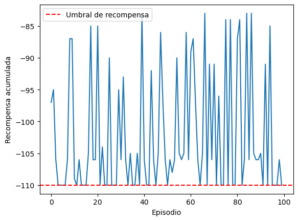

```python
num_episodes = 100
episode_rewards = []

for episode in range(num_episodes):
    state = env.reset()[0]
    total_reward = 0

    while True:
        action = agentDDQN.main_network.get_action(state, epsilon=0)
        next_state, reward, terminated, truncated, _ = env.step(action)

        total_reward += reward

        if terminated or truncated or total_reward == -110:
            break

        state = next_state

    episode_rewards.append(total_reward)

# Se calcula la recompensa media para los 100 episodios:

mean_reward_double = sum(episode_rewards) / num_episodes
print("Recompensa media en 100 episodios:", mean_reward_double)

# Visualizo el gráfico de recompensas por episodio:

plt.plot(episode_rewards)
plt.axhline(y=-110, color='r', linestyle='--', label='Umbral de recompensa')
plt.xlabel('Episodio')
plt.ylabel('Recompensa acumulada')
plt.legend()
plt.show()
```

```python
data = [
    ["DQN", episodes_train_dqn, mean_reward_dqn],
    ["Noisy DQN", episodes_train_noisy, mean_reward_noisy],
    ["Double DQN", episodes_train_double, mean_reward_double]
]

# Define los encabezados de la tabla
headers = ["Agente", "Episodios de Entrenamiento", "Media test con 100 Partidas"]

# Imprime la tabla
table = tabulate(data, headers, tablefmt="pipe")
print(table)
```

```
| Agente     |   Episodios de Entrenamiento |   Media test con 100 Partidas |
|:-----------|-----------------------------:|------------------------------:|
| DQN        |                         1152 |                       -100.4  |
| Noisy DQN  |                         2596 |                       -100.74 |
| Double DQN |                         1817 |                       -102.25 |
```